# Life Expectancy Case Study

## Context

Many studies have been undertaken in the past on factors affecting life expectancy, considering demographic variables, income composition, and mortality rates. It was found that the effect of immunization and human development index was not taken into account in the past studies, and important immunizations like Hepatitis B, Polio, and Diphtheria should also be taken into account. In this case study, we will consider immunization factors, mortality factors, economic factors, social factors, and other health-related factors and use linear regression to see the effect of those factors on Life Expectancy.

## Objective

To analyze the data and build a linear regression model that can predict the life expectancy of the people of a country.

## Key Questions

- Does life expectancy have a positive or negative correlation with the different factors (immunization, mortality, socio-economic, etc.) taken into consideration for the countries?
- Can we build a linear model to predict life expectancy? If yes, how accurate will the model be?

## Data Description

The dataset contains immunization factors, mortality factors, economic factors, social factors, and other health-related factors for different countries across different years.

**Data Dictionary**

- Country: Country
- Year: Year
- Status: Developed or Developing status
- Life expectancy: Life Expectancy in years
- Adult Mortality: Adult Mortality Rates of both sexes (probability of dying between 15 and 60 years per 1000 population)
- Infant deaths: Number of Infant Deaths per 1000 population
- Alcohol: Alcohol, recorded per capita (15+) consumption (in liters of pure alcohol)
- percentage expenditure: Expenditure on health as a percentage of Gross Domestic Product per capita(%)
- Hepatitis B: Hepatitis B (HepB) immunization coverage among 1-year-olds (%)
- Measles: number of reported cases of Measles per 1000 population
- BMI: Average Body Mass Index of the entire population
- under-five deaths: Number of under-five deaths per 1000 population
- Polio: Polio (Pol3) immunization coverage among 1-year-olds (%)
- Total expenditure: General government expenditure on health as a percentage of total government expenditure (%)
- Diphtheria: Diphtheria tetanus toxoid and pertussis (DTP3) immunization coverage among 1-year-olds (%)
- HIV/AIDS: Deaths per 1000 live births due to HIV/AIDS (0-4 years)
- GDP: Gross Domestic Product per capita (in USD)
- Population: Population of the country
- thinness 1-19 years: Prevalence of thinness among children and adolescents for Age 10 to 19 (% )
- thinness 5-9 years: Prevalence of thinness among children for Age 5 to 9(%)
- Income composition of resources: Human Development Index in terms of income composition of resources (index ranging from 0 to 1)
- Schooling: Number of years of schooling

## Let's start coding!

### Importing necessary libraries

```python
# this will help in making the Python code more structured automatically (good coding practice)
%load_ext nb_black

# Libraries to help with reading and manipulating data
import numpy as np
import pandas as pd

# Libraries to help with data visualization
import matplotlib.pyplot as plt
import seaborn as sns

sns.set()

# split the data into train and test
from sklearn.model_selection import train_test_split

# to build linear regression_model
import statsmodels.api as sm

# to check model performance
from sklearn.metrics import mean_absolute_error, mean_squared_error, r2_score
```

```python
# loading the dataset
data = pd.read_csv("Life Expectancy Data.csv")
```

### Data Overview

```python
data.head()
```

|  | Country | Year | Status | Life expectancy | Adult Mortality | Infant deaths | Alcohol | Percentage expenditure | Hepatitis B | Measles | ... | Polio | Total expenditure | Diphtheria | HIV/AIDS | GDP | Population | Thinness 1-19 years | Thinness 5-9 years | Income composition of resources | Schooling |
| --- | --- | --- | --- | --- | --- | --- | --- | --- | --- | --- | --- | --- | --- | --- | --- | --- | --- | --- | --- | --- | --- |
| 0 | Afghanistan | 2015 | Developing | 65.0 | 263.0 | 62 | 0.01 | 71.279624 | 65.0 | 1154 | ... | 6.0 | 8.16 | 65.0 | 0.1 | 584.259210 | 33736494.0 | 17.2 | 17.3 | 0.479 | 10.1 |
| 1 | Afghanistan | 2014 | Developing | 59.9 | 271.0 | 64 | 0.01 | 73.523582 | 62.0 | 492 | ... | 58.0 | 8.18 | 62.0 | 0.1 | 612.696514 | 327582.0 | 17.5 | 17.5 | 0.476 | 10.0 |
| 2 | Afghanistan | 2013 | Developing | 59.9 | 268.0 | 66 | 0.01 | 73.219243 | 64.0 | 430 | ... | 62.0 | 8.13 | 64.0 | 0.1 | 631.744976 | 31731688.0 | 17.7 | 17.7 | 0.470 | 9.9 |
| 3 | Afghanistan | 2012 | Developing | 59.5 | 272.0 | 69 | 0.01 | 78.184215 | 67.0 | 2787 | ... | 67.0 | 8.52 | 67.0 | 0.1 | 669.959000 | 3696958.0 | 17.9 | 18.0 | 0.463 | 9.8 |
| 4 | Afghanistan | 2011 | Developing | 59.2 | 275.0 | 71 | 0.01 | 7.097109 | 68.0 | 3013 | ... | 68.0 | 7.87 | 68.0 | 0.1 | 63.537231 | 2978599.0 | 18.2 | 18.2 | 0.454 | 9.5 |

5 rows × 22 columns

**Observations**

- The first five rows show data for Afghanistan across 5 different years.
- The life expectancy varies from 59.2 to 65 years.
- The *Status* column seems to have text values, which will have to be converted to numerics for modeling purposes.

```python
# check number of rows and columns
data.shape
```

```
(2938, 22)
```

```python
# take a look at the column names
data.columns
```

```
Index(['Country', 'Year', 'Status', 'Life expectancy', 'Adult Mortality',
       'Infant deaths', 'Alcohol', 'Percentage expenditure', 'Hepatitis B',
       'Measles', 'BMI', 'Under-five deaths', 'Polio', 'Total expenditure',
       'Diphtheria', 'HIV/AIDS', 'GDP', 'Population', 'Thinness  1-19 years',
       'Thinness 5-9 years', 'Income composition of resources', 'Schooling'],
      dtype='object')
```

```python
# checking column datatypes and number of non-null values
data.info()
```

```
<class 'pandas.core.frame.DataFrame'>
RangeIndex: 2938 entries, 0 to 2937
Data columns (total 22 columns):
 #   Column                           Non-Null Count  Dtype
---  ------                           --------------  -----
 0   Country                          2938 non-null   object
 1   Year                             2938 non-null   int64
 2   Status                           2938 non-null   object
 3   Life expectancy                  2928 non-null   float64
 4   Adult Mortality                  2928 non-null   float64
 5   Infant deaths                    2938 non-null   int64
 6   Alcohol                          2744 non-null   float64
 7   Percentage expenditure           2938 non-null   float64
 8   Hepatitis B                      2385 non-null   float64
 9   Measles                          2938 non-null   int64
 10  BMI                              2904 non-null   float64
 11  Under-five deaths                2938 non-null   int64
 12  Polio                            2919 non-null   float64
 13  Total expenditure                2712 non-null   float64
 14  Diphtheria                       2919 non-null   float64
 15  HIV/AIDS                         2938 non-null   float64
 16  GDP                              2490 non-null   float64
 17  Population                       2286 non-null   float64
 18  Thinness  1-19 years             2904 non-null   float64
 19  Thinness 5-9 years               2904 non-null   float64
 20  Income composition of resources  2771 non-null   float64
 21  Schooling                        2775 non-null   float64
dtypes: float64(16), int64(4), object(2)
memory usage: 505.1+ KB
```

**Observations**

- Most of the columns in the data are numeric in nature (integer or float).
- `Country` and `Status` columns are of *object* type, which means they have text values.
- Some columns seem to have null (or missing) values too.

```python
# Let's look at the statistical summary of the data
data.describe(include="all").T
```

|  | count | unique | top | freq | mean | std | min | 25% | 50% | 75% | max |
| --- | --- | --- | --- | --- | --- | --- | --- | --- | --- | --- | --- |
| Country | 2938 | 193 | Honduras | 16 | NaN | NaN | NaN | NaN | NaN | NaN | NaN |
| Year | 2938 | NaN | NaN | NaN | 2007.52 | 4.61384 | 2000 | 2004 | 2008 | 2012 | 2015 |
| Status | 2938 | 2 | Developing | 2426 | NaN | NaN | NaN | NaN | NaN | NaN | NaN |
| Life expectancy | 2928 | NaN | NaN | NaN | 69.2249 | 9.52387 | 36.3 | 63.1 | 72.1 | 75.7 | 89 |
| Adult Mortality | 2928 | NaN | NaN | NaN | 164.796 | 124.292 | 1 | 74 | 144 | 228 | 723 |
| Infant deaths | 2938 | NaN | NaN | NaN | 30.3039 | 117.927 | 0 | 0 | 3 | 22 | 1800 |
| Alcohol | 2744 | NaN | NaN | NaN | 4.60286 | 4.05241 | 0.01 | 0.8775 | 3.755 | 7.7025 | 17.87 |
| Percentage expenditure | 2938 | NaN | NaN | NaN | 738.251 | 1987.91 | 0 | 4.68534 | 64.9129 | 441.534 | 19479.9 |
| Hepatitis B | 2385 | NaN | NaN | NaN | 80.9405 | 25.07 | 1 | 77 | 92 | 97 | 99 |
| Measles | 2938 | NaN | NaN | NaN | 2419.59 | 11467.3 | 0 | 0 | 17 | 360.25 | 212183 |
| BMI | 2904 | NaN | NaN | NaN | 38.3212 | 20.044 | 1 | 19.3 | 43.5 | 56.2 | 87.3 |
| Under-five deaths | 2938 | NaN | NaN | NaN | 42.0357 | 160.446 | 0 | 0 | 4 | 28 | 2500 |
| Polio | 2919 | NaN | NaN | NaN | 82.5502 | 23.428 | 3 | 78 | 93 | 97 | 99 |
| Total expenditure | 2712 | NaN | NaN | NaN | 5.93819 | 2.49832 | 0.37 | 4.26 | 5.755 | 7.4925 | 17.6 |
| Diphtheria | 2919 | NaN | NaN | NaN | 82.3241 | 23.7169 | 2 | 78 | 93 | 97 | 99 |
| HIV/AIDS | 2938 | NaN | NaN | NaN | 1.7421 | 5.07778 | 0.1 | 0.1 | 0.1 | 0.8 | 50.6 |
| GDP | 2490 | NaN | NaN | NaN | 7483.16 | 14270.2 | 1.68135 | 463.936 | 1766.95 | 5910.81 | 119173 |
| Population | 2286 | NaN | NaN | NaN | 1.27534e+07 | 6.10121e+07 | 34 | 195793 | 1.38654e+06 | 7.42036e+06 | 1.29386e+09 |
| Thinness 1-19 years | 2904 | NaN | NaN | NaN | 4.8397 | 4.42019 | 0.1 | 1.6 | 3.3 | 7.2 | 27.7 |
| Thinness 5-9 years | 2904 | NaN | NaN | NaN | 4.87032 | 4.50888 | 0.1 | 1.5 | 3.3 | 7.2 | 28.6 |
| Income composition of resources | 2771 | NaN | NaN | NaN | 0.627551 | 0.210904 | 0 | 0.493 | 0.677 | 0.779 | 0.948 |
| Schooling | 2775 | NaN | NaN | NaN | 11.9928 | 3.35892 | 0 | 10.1 | 12.3 | 14.3 | 20.7 |

**Observations**

- There are 193 countries in the dataset.
- Most of the countries in the dataset are developing countries.
- The average life expectancy is ~69 years.

**Let's fix the missing values.**

- For the target variable (`Life expectancy`), we will drop the missing values.
- For the predictor variables, we will replace the missing values in each column with its median.

```python
# we first create a copy of the original data to avoid changes to it
df = data.copy()
```

```python
# dropping missing values in the target
df.dropna(subset=["Life expectancy"], inplace=True)
```

```python
# filling missing values using the column median for the predictor variables
medianFiller = lambda x: x.fillna(x.median())
numeric_columns = df.select_dtypes(include=np.number).columns.tolist()
df[numeric_columns] = df[numeric_columns].apply(medianFiller, axis=0)
```

```python
# checking the number of missing values
df.isnull().sum()
```

```
Country                            0
Year                               0
Status                             0
Life expectancy                    0
Adult Mortality                    0
Infant deaths                      0
Alcohol                            0
Percentage expenditure             0
Hepatitis B                        0
Measles                            0
BMI                                0
Under-five deaths                  0
Polio                              0
Total expenditure                  0
Diphtheria                         0
HIV/AIDS                           0
GDP                                0
Population                         0
Thinness  1-19 years               0
Thinness 5-9 years                 0
Income composition of resources    0
Schooling                          0
dtype: int64
```

- All the missing values have been treated.

```python
# check the number of unique values in each column of the dataframe
df.nunique()
```

```
Country                             183
Year                                 16
Status                                2
Life expectancy                     362
Adult Mortality                     425
Infant deaths                       209
Alcohol                            1076
Percentage expenditure             2323
Hepatitis B                          87
Measles                             958
BMI                                 603
Under-five deaths                   252
Polio                                73
Total expenditure                   816
Diphtheria                           81
HIV/AIDS                            200
GDP                                2485
Population                         2278
Thinness  1-19 years                200
Thinness 5-9 years                  207
Income composition of resources     625
Schooling                           173
dtype: int64
```

**Observations**

- The *Status* column has 2 unique values - "*Developing*" and "*Developed*"
- The *Country* column has 183 unique values, i.e., the data is collected from 183 countries.

**We know that the datatype of two columns (`Status` and `Country`) is object. So, we need to convert them to categorical type for further processing in the next steps.**

**Before we further process the data, let's take a look at the graphical visualization of the data to understand it in a better way.**

## EDA

### Univariate analysis

```python
# function to plot a boxplot and a histogram along the same scale.


def histogram_boxplot(data, feature, figsize=(12, 7), kde=False, bins=None):
    """
    Boxplot and histogram combined

    data: dataframe
    feature: dataframe column
    figsize: size of figure (default (12,7))
    kde: whether to the show density curve (default False)
    bins: number of bins for histogram (default None)
    """
    f2, (ax_box2, ax_hist2) = plt.subplots(
        nrows=2,  # Number of rows of the subplot grid= 2
        sharex=True,  # x-axis will be shared among all subplots
        gridspec_kw={"height_ratios": (0.25, 0.75)},
        figsize=figsize,
    )  # creating the 2 subplots
    sns.boxplot(
        data=data, x=feature, ax=ax_box2, showmeans=True, color="violet"
    )  # boxplot will be created and a star will indicate the mean value of the column
    sns.histplot(
        data=data, x=feature, kde=kde, ax=ax_hist2, bins=bins, palette="winter"
    ) if bins else sns.histplot(
        data=data, x=feature, kde=kde, ax=ax_hist2
    )  # For histogram
    ax_hist2.axvline(
        data[feature].mean(), color="green", linestyle="--"
    )  # Add mean to the histogram
    ax_hist2.axvline(
        data[feature].median(), color="black", linestyle="-"
    )  # Add median to the histogram
```

**Let's explore the dependent variable *Life expectancy***

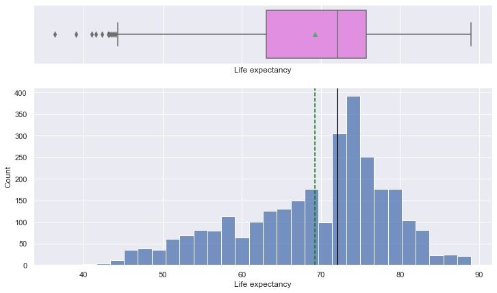

```python
histogram_boxplot(df, "Life expectancy")
```

**Let's explore per capita alcohol consumption**

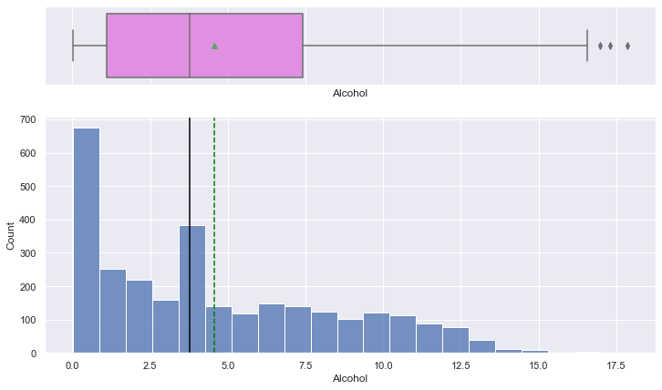

```python
histogram_boxplot(df, "Alcohol")
```

**Observations**

- The median alcohol consumption is 3.75 litres.
- There are some outliers where average alcohol consumption is more than 15 litres.
- The distribution is right-skewed.

**Let's explore GDP**

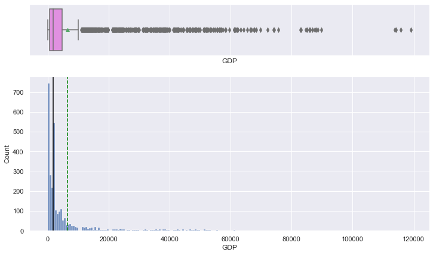

```python
histogram_boxplot(df, "GDP")
```

**Observations**

- The distribution of GDP is heavily skewed to the right.
- The outliers to the right indicate that many countries have a very high GDP.

```python
# function to create labeled barplots


def labeled_barplot(data, feature, perc=False, n=None):
    """
    Barplot with percentage at the top

    data: dataframe
    feature: dataframe column
    perc: whether to display percentages instead of count (default is False)
    n: displays the top n category levels (default is None, i.e., display all levels)
    """

    total = len(data[feature])  # length of the column
    count = data[feature].nunique()
    if n is None:
        plt.figure(figsize=(count + 1, 5))
    else:
        plt.figure(figsize=(n + 1, 5))

    plt.xticks(rotation=90, fontsize=15)
    ax = sns.countplot(
        data=data,
        x=feature,
        palette="Paired",
        order=data[feature].value_counts().index[:n].sort_values(),
    )

    for p in ax.patches:
        if perc == True:
            label = "{:.1f}%".format(
                100 * p.get_height() / total
            )  # percentage of each class of the category
        else:
            label = p.get_height()  # count of each level of the category

        x = p.get_x() + p.get_width() / 2  # width of the plot
        y = p.get_height()  # height of the plot

        ax.annotate(
            label,
            (x, y),
            ha="center",
            va="center",
            size=12,
            xytext=(0, 5),
            textcoords="offset points",
        )  # annotate the percentage

    plt.show()  # show the plot
```

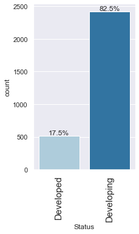

```python
labeled_barplot(df, "Status", perc=True)
```

- More than 80% of the countries in the data are developing countries.

### Bivariate Analysis

**Let's look at correlations.**

```python
# correlation of all attributes with life expectancy
df[df.columns[:]].corr()["Life expectancy"][:]
```

```
Year                               0.170033
Life expectancy                    1.000000
Adult Mortality                   -0.696359
Infant deaths                     -0.196557
Alcohol                            0.390674
Percentage expenditure             0.381864
Hepatitis B                        0.171255
Measles                           -0.157586
BMI                                0.558888
Under-five deaths                 -0.222529
Polio                              0.459458
Total expenditure                  0.209588
Diphtheria                         0.473268
HIV/AIDS                          -0.556556
GDP                                0.430991
Population                        -0.028842
Thinness  1-19 years              -0.467859
Thinness 5-9 years                -0.462645
Income composition of resources    0.688591
Schooling                          0.717314
Name: Life expectancy, dtype: float64
```

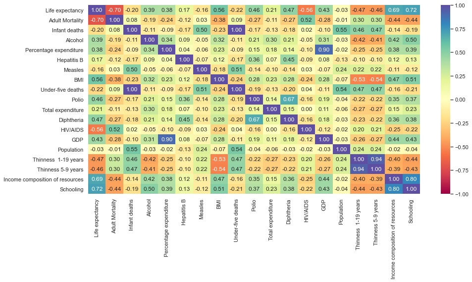

```python
numeric_columns = data.select_dtypes(include=np.number).columns.tolist()
numeric_columns.remove("Year")  # dropping year column as it is temporal variable

# correlation heatmap
plt.figure(figsize=(15, 7))
sns.heatmap(
    df[numeric_columns].corr(),
    annot=True,
    vmin=-1,
    vmax=1,
    fmt=".2f",
    cmap="Spectral",
)
plt.show()
```

**Observations**

- `Life expectancy` is highly negatively correlated with `Adult Mortality` and `HIV/AIDs`, which means that as adult mortality and HIV death (0-4 years) increases, life expectancy tends to decrease.
- `Life expectancy` is highly positively correlated with `Schooling` and `Income composition of resources`, which means that as schooling years of citizens in a country and income composition of resources increases, life expectancy tends to increase.

**Let's look at the graphs of a few variables that are highly correlated with `Life expectancy`.**

**`Life expectancy` vs `HIV/AIDS` vs `Status`**

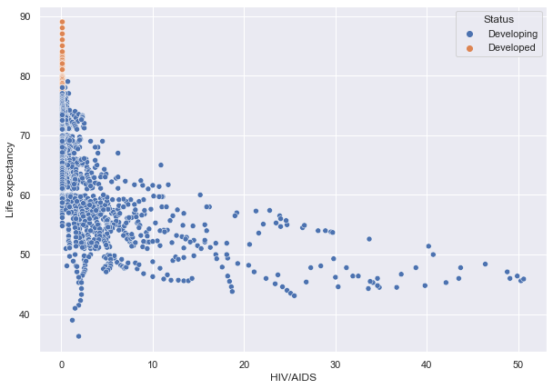

```python
plt.figure(figsize=(10, 7))
sns.scatterplot(y="Life expectancy", x="HIV/AIDS", hue="Status", data=df)
plt.show()
```

- Developed countries have very low cases of HIV/AIDS.

**`Life expectancy` vs `Schooling` vs `Status`**

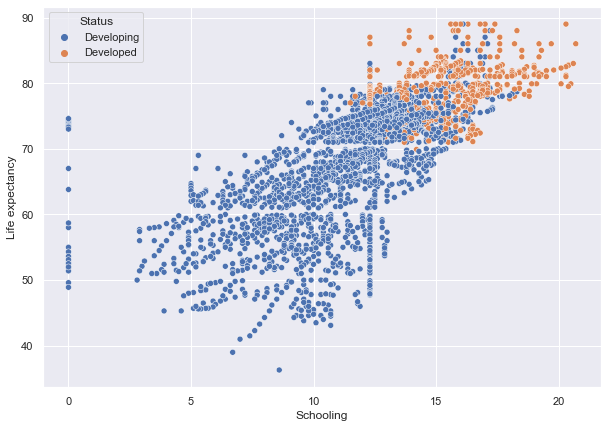

```python
plt.figure(figsize=(10, 7))
sns.scatterplot(y="Life expectancy", x="Schooling", hue="Status", data=df)
plt.show()
```

**Observations**

- Majority of the developed countries have schooling of more than 13 years.
- Developing countries have a higher variance in schooling years.

**Let's check the variation in life expectancy across years.**

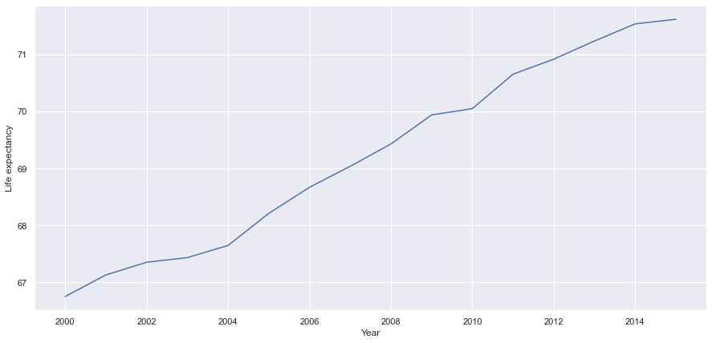

```python
# average life expectancy over the years
plt.figure(figsize=(15, 7))
sns.lineplot(x="Year", y="Life expectancy", data=df, ci=None)
plt.show()
```

- Overall life expectancy of the world population is increasing over the years.

### Column binning

- Let's group all countries into continents to avoid having too many dummy variables while modeling.

```python
# Installing library to group coutries into continenets
# Please uncomment the next line and run the cell to install the library

#!pip install pycountry-convert
```

```python
# Let's group coutries into continents
import pycountry_convert as pc


def country_to_continent(country_name):
    """
    country_name : name of country for which continent is needed
    """
    if "(" in country_name:
        country_name = country_name.split(" ")[0]
    country_alpha2 = pc.country_name_to_country_alpha2(country_name)
    country_continent_code = pc.country_alpha2_to_continent_code(country_alpha2)
    country_continent_name = pc.convert_continent_code_to_continent_name(
        country_continent_code
    )
    return country_continent_name
```

```python
df.Country.apply(country_to_continent)
```

[output not shown]

- Above error is arising because names of the countries are different from what the library has.
- In order to resolve this, we looked at all country names that caused this error and hard-coded them as shown below.

```python
loc = df.Country.tolist()
continent = dict()

# hard-coding the continent names of those countries which were giving error with country_to_continent function
for cn in loc:
    if cn == "Republic of Korea":
        continent[cn] = "Asia"
    elif cn == "The former Yugoslav republic of Macedonia":
        continent[cn] = "Europe"
    elif cn == "Timor-Leste":
        continent[cn] = "Asia"
    else:
        continent[cn] = country_to_continent(cn)
```

```python
# mapping every country to its continent
df["Continent"] = df["Country"].map(continent)
```

```python
# let us look at unique continents
print(df["Country"].map(continent).unique())
```

```
['Asia' 'Europe' 'Africa' 'North America' 'South America' 'Oceania']
```

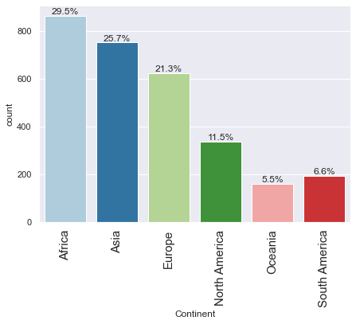

```python
labeled_barplot(df, "Continent", perc=True)
```

**Observations**

- More than 75% of the data points are from Africa, Asia, and Europe.
- Oceania accounts for only 5.5% of the data points.

**`Life expectancy` vs `Adult Mortality` vs `Continent`**

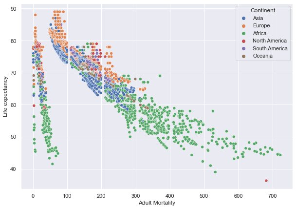

```python
plt.figure(figsize=(10, 7))
sns.scatterplot(y="Life expectancy", x="Adult Mortality", hue="Continent", data=df)
plt.show()
```

- Many European countries have had life expectancy higher than 80 years for some years.
- Most of the African countries have higher adult mortality and life expectancy lower than 65 years.

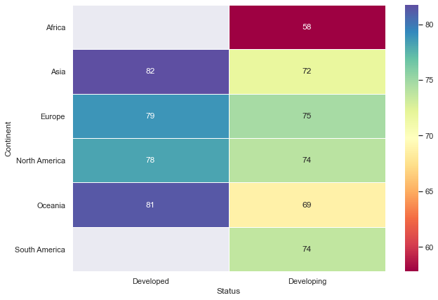

```python
df_hm = df.pivot_table(
    index="Continent", columns="Status", values="Life expectancy", aggfunc=np.median
)

# Draw a heatmap
f, ax = plt.subplots(figsize=(10, 7))
sns.heatmap(df_hm, cmap="Spectral", linewidths=0.5, annot=True, ax=ax)
plt.show()
```

- Developed countries from Asia have the highest life expectancy.

**Let's convert the *object* type columns to *category* type**

```python
df["Country"] = df["Country"].astype("category")
df["Status"] = df["Status"].astype("category")
df["Continent"] = df["Continent"].astype("category")
```

## Linear Model Building

1. We want to predict the life expectancy.
2. Before we proceed to build a model, we'll have to encode categorical features.
3. We'll split the data into train and test to be able to evaluate the model that we build on the train data.
4. We will build a Linear Regression model using the train data and then check it's performance.

```python
# defining X and y variables
X = df.drop(["Life expectancy", "Country"], axis=1)
y = df["Life expectancy"]

print(X.head())
print(y.head())
```

```
   Year      Status  Adult Mortality  Infant deaths  Alcohol  \
0  2015  Developing            263.0             62     0.01
1  2014  Developing            271.0             64     0.01
2  2013  Developing            268.0             66     0.01
3  2012  Developing            272.0             69     0.01
4  2011  Developing            275.0             71     0.01

   Percentage expenditure  Hepatitis B  Measles   BMI  Under-five deaths  ...  \
0               71.279624         65.0     1154  19.1                 83  ...
1               73.523582         62.0      492  18.6                 86  ...
2               73.219243         64.0      430  18.1                 89  ...
3               78.184215         67.0     2787  17.6                 93  ...
4                7.097109         68.0     3013  17.2                 97  ...

   Total expenditure  Diphtheria  HIV/AIDS         GDP  Population  \
```

[output cut: 27 more lines]

```python
# let's add the intercept to data
X = sm.add_constant(X)
```

```python
X = pd.get_dummies(
    X,
    columns=X.select_dtypes(include=["object", "category"]).columns.tolist(),
    drop_first=True,
)
X.head()
```

|  | const | Year | Adult Mortality | Infant deaths | Alcohol | Percentage expenditure | Hepatitis B | Measles | BMI | Under-five deaths | ... | Thinness 1-19 years | Thinness 5-9 years | Income composition of resources | Schooling | Status_Developing | Continent_Asia | Continent_Europe | Continent_North America | Continent_Oceania | Continent_South America |
| --- | --- | --- | --- | --- | --- | --- | --- | --- | --- | --- | --- | --- | --- | --- | --- | --- | --- | --- | --- | --- | --- |
| 0 | 1.0 | 2015 | 263.0 | 62 | 0.01 | 71.279624 | 65.0 | 1154 | 19.1 | 83 | ... | 17.2 | 17.3 | 0.479 | 10.1 | 1 | 1 | 0 | 0 | 0 | 0 |
| 1 | 1.0 | 2014 | 271.0 | 64 | 0.01 | 73.523582 | 62.0 | 492 | 18.6 | 86 | ... | 17.5 | 17.5 | 0.476 | 10.0 | 1 | 1 | 0 | 0 | 0 | 0 |
| 2 | 1.0 | 2013 | 268.0 | 66 | 0.01 | 73.219243 | 64.0 | 430 | 18.1 | 89 | ... | 17.7 | 17.7 | 0.470 | 9.9 | 1 | 1 | 0 | 0 | 0 | 0 |
| 3 | 1.0 | 2012 | 272.0 | 69 | 0.01 | 78.184215 | 67.0 | 2787 | 17.6 | 93 | ... | 17.9 | 18.0 | 0.463 | 9.8 | 1 | 1 | 0 | 0 | 0 | 0 |
| 4 | 1.0 | 2011 | 275.0 | 71 | 0.01 | 7.097109 | 68.0 | 3013 | 17.2 | 97 | ... | 18.2 | 18.2 | 0.454 | 9.5 | 1 | 1 | 0 | 0 | 0 | 0 |

5 rows × 26 columns

```python
# splitting the data in 70:30 ratio for train to test data

x_train, x_test, y_train, y_test = train_test_split(X, y, test_size=0.3, random_state=1)
```

```python
print("Number of rows in train data =", x_train.shape[0])
print("Number of rows in test data =", x_test.shape[0])
```

```
Number of rows in train data = 2049
Number of rows in test data = 879
```

```python
olsmodel = sm.OLS(y_train, x_train).fit()
print(olsmodel.summary())
```

```
                            OLS Regression Results
==============================================================================
Dep. Variable:        Life expectancy   R-squared:                       0.847
Model:                            OLS   Adj. R-squared:                  0.845
Method:                 Least Squares   F-statistic:                     448.3
Date:                Fri, 08 Oct 2021   Prob (F-statistic):               0.00
Time:                        10:30:10   Log-Likelihood:                -5612.6
No. Observations:                2049   AIC:                         1.128e+04
Df Residuals:                    2023   BIC:                         1.142e+04
Df Model:                          25
Covariance Type:            nonrobust
===================================================================================================
                                      coef    std err          t      P>|t|      [0.025      0.975]
---------------------------------------------------------------------------------------------------
const                             -10.0359     39.682     -0.253      0.800     -87.858      67.786
Year                                0.0334      0.020      1.683      0.093      -0.006       0.072
Adult Mortality                    -0.0162      0.001    -17.946      0.000      -0.018      -0.014
Infant deaths                       0.0639      0.010      6.511      0.000       0.045       0.083
Alcohol                            -0.0505      0.033     -1.508      0.132      -0.116       0.015
Percentage expenditure              0.0002   9.93e-05      1.695      0.090   -2.64e-05       0.000
Hepatitis B                        -0.0145      0.004     -3.393      0.001      -0.023      -0.006
Measles                         -1.559e-05   9.27e-06     -1.682      0.093   -3.38e-05    2.58e-06
BMI                                 0.0339      0.006      5.772      0.000       0.022       0.045
Under-five deaths                  -0.0485      0.007     -6.750      0.000      -0.063      -0.034
Polio                               0.0323      0.005      6.551      0.000       0.023       0.042
Total expenditure                  -0.0060      0.039     -0.152      0.879      -0.083       0.071
Diphtheria                          0.0309      0.005      6.014      0.000       0.021       0.041
HIV/AIDS                           -0.3832      0.020    -18.797      0.000      -0.423      -0.343
GDP                              2.496e-05    1.5e-05      1.663      0.096   -4.47e-06    5.44e-05
Population                       3.075e-10   2.31e-09      0.133      0.894   -4.22e-09    4.84e-09
Thinness  1-19 years               -0.0236      0.061     -0.385      0.700      -0.143       0.096
Thinness 5-9 years                 -0.0729      0.061     -1.198      0.231      -0.192       0.046
Income composition of resources     4.0795      0.721      5.658      0.000       2.665       5.494
Schooling                           0.6186      0.048     12.880      0.000       0.524       0.713
Status_Developing                  -2.5795      0.352     -7.318      0.000      -3.271      -1.888
Continent_Asia                      4.2862      0.287     14.922      0.000       3.723       4.850
Continent_Europe                    3.9647      0.413      9.597      0.000       3.155       4.775
Continent_North America             5.8618      0.366     16.031      0.000       5.145       6.579
Continent_Oceania                   2.4254      0.459      5.286      0.000       1.526       3.325
Continent_South America             3.9444      0.445      8.860      0.000       3.071       4.817
==============================================================================
Omnibus:                       79.914   Durbin-Watson:                   2.016
Prob(Omnibus):                  0.000   Jarque-Bera (JB):              212.485
Skew:                          -0.142   Prob(JB):                     7.24e-47
Kurtosis:                       4.552   Cond. No.                     2.09e+10
==============================================================================

Notes:
[1] Standard Errors assume that the covariance matrix of the errors is correctly specified.
[2] The condition number is large, 2.09e+10. This might indicate that there are
strong multicollinearity or other numerical problems.
```

### Interpreting the Regression Results:

1. **Adjusted. R-squared**: It reflects the fit of the model.
   - Adjusted R-squared values generally range from 0 to 1, where a higher value generally indicates a better fit, assuming certain conditions are met.
   - In our case, the value for adj. R-squared is **0.845**, which is good!
1. *const* coefficient: It is the Y-intercept.
   - It means that if all the predictor variable coefficients are zero, then the expected output (i.e., Y) would be equal to the *const* coefficient.
   - In our case, the value for *const* coefficient is **-10.0359**
1. **Coefficient of a predictor variable**: It represents the change in the output Y due to a change in the predictor variable (everything else held constant).
   - In our case, the coefficient of `Adult Mortality` is -0.0162.

**Let's check the performance of the model using different metrics.**

- We will be using metric functions defined in sklearn for RMSE, MAE, and $R^2$.
- We will define a function to calculate MAPE and adjusted $R^2$.
  - The mean absolute percentage error (MAPE) measures the accuracy of predictions as a percentage, and can be calculated as the average absolute percent error for each predicted value minus actual values divided by actual values. It works best if there are no extreme values in the data and none of the actual values are 0.
- We will create a function which will print out all the above metrics in one go.

```python
# function to compute adjusted R-squared
def adj_r2_score(predictors, targets, predictions):
    r2 = r2_score(targets, predictions)
    n = predictors.shape[0]
    k = predictors.shape[1]
    return 1 - ((1 - r2) * (n - 1) / (n - k - 1))


# function to compute MAPE
def mape_score(targets, predictions):
    return np.mean(np.abs(targets - predictions) / targets) * 100


# function to compute different metrics to check performance of a regression model
def model_performance_regression(model, predictors, target):
    """
    Function to compute different metrics to check regression model performance

    model: regressor
    predictors: independent variables
    target: dependent variable
    """

    # predicting using the independent variables
    pred = model.predict(predictors)

    r2 = r2_score(target, pred)  # to compute R-squared
    adjr2 = adj_r2_score(predictors, target, pred)  # to compute adjusted R-squared
    rmse = np.sqrt(mean_squared_error(target, pred))  # to compute RMSE
    mae = mean_absolute_error(target, pred)  # to compute MAE
    mape = mape_score(target, pred)  # to compute MAPE

    # creating a dataframe of metrics
    df_perf = pd.DataFrame(
        {
            "RMSE": rmse,
            "MAE": mae,
            "R-squared": r2,
            "Adj. R-squared": adjr2,
            "MAPE": mape,
        },
        index=[0],
    )

    return df_perf
```

```python
# checking model performance on train set (seen 70% data)
print("Training Performance\n")
olsmodel_train_perf = model_performance_regression(olsmodel, x_train, y_train)
olsmodel_train_perf
```

```
Training Performance
```

|  | RMSE | MAE | R-squared | Adj. R-squared | MAPE |
| --- | --- | --- | --- | --- | --- |
| 0 | 3.7444 | 2.832731 | 0.847098 | 0.845132 | 4.308428 |

```python
# checking model performance on test set (seen 30% data)
print("Test Performance\n")
olsmodel_test_perf = model_performance_regression(olsmodel, x_test, y_test)
olsmodel_test_perf
```

```
Test Performance
```

|  | RMSE | MAE | R-squared | Adj. R-squared | MAPE |
| --- | --- | --- | --- | --- | --- |
| 0 | 3.730845 | 2.820497 | 0.842311 | 0.837499 | 4.280578 |

**Observations**

- The training $R^2$ is 0.85, so the model is not underfitting.
- The train and test RMSE and MAE are comparable, so the model is not overfitting either.
- MAE suggests that the model can predict life expectancy within a mean error of 2.8 years on the test data.
- MAPE of 4.3 on the test data means that we are able to predict within 4.3% of the life expectancy.

## Checking Linear Regression Assumptions

We will be checking the following Linear Regression assumptions:

1. **No Multicollinearity**
2. **Linearity of variables**
3. **Independence of error terms**
4. **Normality of error terms**
5. **No Heteroscedasticity**

### TEST FOR MULTICOLLINEARITY

- Multicollinearity occurs when predictor variables in a regression model are correlated. This correlation is a problem because predictor variables should be independent. If the correlation between variables is high, it can cause problems when we fit the model and interpret the results. When we have multicollinearity in the linear model, the coefficients that the model suggests are unreliable.
- There are different ways of detecting (or testing) multicollinearity. One such way is by using the Variance Inflation Factor, or VIF.
- **Variance Inflation Factor (VIF)**: Variance inflation factors measure the inflation in the variances of the regression parameter estimates due to collinearities that exist among the predictors. It is a measure of how much the variance of the estimated regression coefficient $\beta_k$ is "inflated" by the existence of correlation among the predictor variables in the model.
  - If VIF is 1, then there is no correlation among the $k$th predictor and the remaining predictor variables, and hence, the variance of $\beta_k$ is not inflated at all.
- **General Rule of thumb**:
  - If VIF is between 1 and 5, then there is low multicollinearity.
  - If VIF is between 5 and 10, we say there is moderate multicollinearity.
  - If VIF is exceeding 10, it shows signs of high multicollinearity.

```python
from statsmodels.stats.outliers_influence import variance_inflation_factor

# we will define a function to check VIF
def checking_vif(predictors):
    vif = pd.DataFrame()
    vif["feature"] = predictors.columns

    # calculating VIF for each feature
    vif["VIF"] = [
        variance_inflation_factor(predictors.values, i)
        for i in range(len(predictors.columns))
    ]
    return vif
```

```python
checking_vif(x_train)
```

|  | feature | VIF |
| --- | --- | --- |
| 0 | const | 227205.392829 |
| 1 | Year | 1.191704 |
| 2 | Adult Mortality | 1.835454 |
| 3 | Infant deaths | 191.008892 |
| 4 | Alcohol | 2.470353 |
| 5 | Percentage expenditure | 5.631140 |
| 6 | Hepatitis B | 1.322443 |
| 7 | Measles | 1.432634 |
| 8 | BMI | 1.921698 |
| 9 | Under-five deaths | 190.547440 |
| 10 | Polio | 1.909524 |
| 11 | Total expenditure | 1.250291 |
| 12 | Diphtheria | 2.107072 |
| 13 | HIV/AIDS | 1.569409 |
| 14 | GDP | 5.871180 |
| 15 | Population | 1.410645 |
| 16 | Thinness 1-19 years | 9.874031 |
| 17 | Thinness 5-9 years | 10.052169 |
| 18 | Income composition of resources | 3.179681 |
| 19 | Schooling | 3.534133 |
| 20 | Status_Developing | 2.590817 |
| 21 | Continent_Asia | 2.242959 |
| 22 | Continent_Europe | 4.110731 |
| 23 | Continent_North America | 2.009284 |
| 24 | Continent_Oceania | 1.635813 |
| 25 | Continent_South America | 1.625837 |

- `Thinness__1_19_years`,`Thinness__5_9_years`, `Percentage expenditure`, and `GDP` have VIFs slightly greater than 5.
- `Infant_deaths` and `Under_five_deaths` have a VIF score of much greater than 5.
  - Clearly these 2 variables are correlated with each other.
  - This does seem to make intuitive sense because the number of infant death and under-5 deaths would have a significant overlap.

### Removing Multicollinearity

To remove multicollinearity

1. Drop every column one by one that has a VIF score greater than 5.
2. Look at the adjusted R-squared and RMSE of all these models.
3. Drop the variable that makes the least change in adjusted R-squared.
4. Check the VIF scores again.
5. Continue till you get all VIF scores under 5.

Let's define a function that will help us do this.

```python
def treating_multicollinearity(predictors, target, high_vif_columns):
    """
    Checking the effect of dropping the columns showing high multicollinearity
    on model performance (adj. R-squared and RMSE)

    predictors: independent variables
    target: dependent variable
    high_vif_columns: columns having high VIF
    """
    # empty lists to store adj. R-squared and RMSE values
    adj_r2 = []
    rmse = []

    # build ols models by dropping one of the high VIF columns at a time
    # store the adjusted R-squared and RMSE in the lists defined previously
    for cols in high_vif_columns:
        # defining the new train set
        train = predictors.loc[:, ~predictors.columns.str.startswith(cols)]

        # create the model
        olsmodel = sm.OLS(target, train).fit()

        # adding adj. R-squared and RMSE to the lists
        adj_r2.append(olsmodel.rsquared_adj)
        rmse.append(np.sqrt(olsmodel.mse_resid))

    # creating a dataframe for the results
    temp = pd.DataFrame(
        {
            "col": high_vif_columns,
            "Adj. R-squared after_dropping col": adj_r2,
            "RMSE after dropping col": rmse,
        }
    ).sort_values(by="Adj. R-squared after_dropping col", ascending=False)
    temp.reset_index(drop=True, inplace=True)

    return temp
```

```python
col_list = [
    "Infant deaths",
    "Under-five deaths",
    "Percentage expenditure",
    "GDP",
    "Thinness  1-19 years",
    "Thinness 5-9 years",
]

res = treating_multicollinearity(x_train, y_train, col_list)
res
```

|  | col | Adj. R-squared after_dropping col | RMSE after dropping col |
| --- | --- | --- | --- |
| 0 | Thinness 1-19 years | 0.845273 | 3.767592 |
| 1 | Thinness 5-9 years | 0.845175 | 3.768790 |
| 2 | GDP | 0.845073 | 3.770029 |
| 3 | Percentage expenditure | 0.845065 | 3.770129 |
| 4 | Infant deaths | 0.842042 | 3.806727 |
| 5 | Under-five deaths | 0.841800 | 3.809645 |

- Dropping `Under-five deaths` would have the maximum impact on the predictive power of the model (amongst the variables being considered).
- We'll drop `Thinness 1-19 years` and check the VIF again.

```python
col_to_drop = "Thinness  1-19 years"
x_train2 = x_train.loc[:, ~x_train.columns.str.startswith(col_to_drop)]
x_test2 = x_test.loc[:, ~x_test.columns.str.startswith(col_to_drop)]

# Check VIF now
vif = checking_vif(x_train2)
print("VIF after dropping ", col_to_drop)
vif
```

```
VIF after dropping  Thinness  1-19 years
```

|  | feature | VIF |
| --- | --- | --- |
| 0 | const | 227163.382376 |
| 1 | Year | 1.191427 |
| 2 | Adult Mortality | 1.835454 |
| 3 | Infant deaths | 190.684749 |
| 4 | Alcohol | 2.465115 |
| 5 | Percentage expenditure | 5.631131 |
| 6 | Hepatitis B | 1.322159 |
| 7 | Measles | 1.432441 |
| 8 | BMI | 1.920484 |
| 9 | Under-five deaths | 190.336121 |
| 10 | Polio | 1.907730 |
| 11 | Total expenditure | 1.250287 |
| 12 | Diphtheria | 2.105441 |
| 13 | HIV/AIDS | 1.569208 |
| 14 | GDP | 5.870923 |
| 15 | Population | 1.410503 |
| 16 | Thinness 5-9 years | 2.298109 |
| 17 | Income composition of resources | 3.177579 |
| 18 | Schooling | 3.534092 |
| 19 | Status_Developing | 2.590815 |
| 20 | Continent_Asia | 2.239828 |
| 21 | Continent_Europe | 4.096344 |
| 22 | Continent_North America | 2.003104 |
| 23 | Continent_Oceania | 1.625101 |
| 24 | Continent_South America | 1.622022 |

- Dropping `Thinness 1-19 years` has brought the VIF of `Thinness 5-9 years` below 5.
- `Infant deaths` and `Under-five deaths` still have a VIF score of much greater than 5.

```python
col_list = [
    "Infant deaths",
    "Under-five deaths",
    "Percentage expenditure",
    "GDP",
]

res = treating_multicollinearity(x_train2, y_train, col_list)
res
```

|  | col | Adj. R-squared after_dropping col | RMSE after dropping col |
| --- | --- | --- | --- |
| 0 | GDP | 0.845139 | 3.769228 |
| 1 | Percentage expenditure | 0.845130 | 3.769338 |
| 2 | Infant deaths | 0.842119 | 3.805800 |
| 3 | Under-five deaths | 0.841876 | 3.808728 |

- We will drop `GDP` next.

```python
col_to_drop = "GDP"
x_train3 = x_train2.loc[:, ~x_train2.columns.str.startswith(col_to_drop)]
x_test3 = x_test2.loc[:, ~x_test2.columns.str.startswith(col_to_drop)]

# Check VIF now
vif = checking_vif(x_train3)
print("VIF after dropping ", col_to_drop)
vif
```

```
VIF after dropping  GDP
```

|  | feature | VIF |
| --- | --- | --- |
| 0 | const | 224205.117775 |
| 1 | Year | 1.175926 |
| 2 | Adult Mortality | 1.833756 |
| 3 | Infant deaths | 190.073929 |
| 4 | Alcohol | 2.454605 |
| 5 | Percentage expenditure | 1.383310 |
| 6 | Hepatitis B | 1.321552 |
| 7 | Measles | 1.432193 |
| 8 | BMI | 1.914150 |
| 9 | Under-five deaths | 189.710454 |
| 10 | Polio | 1.905124 |
| 11 | Total expenditure | 1.228239 |
| 12 | Diphtheria | 2.105384 |
| 13 | HIV/AIDS | 1.566821 |
| 14 | Population | 1.410490 |
| 15 | Thinness 5-9 years | 2.289516 |
| 16 | Income composition of resources | 3.166265 |
| 17 | Schooling | 3.523918 |
| 18 | Status_Developing | 2.580709 |
| 19 | Continent_Asia | 2.221620 |
| 20 | Continent_Europe | 4.096308 |
| 21 | Continent_North America | 2.003063 |
| 22 | Continent_Oceania | 1.617673 |
| 23 | Continent_South America | 1.621238 |

- Dropping `GDP` has brought the VIF of `Percentage expenditure` below 5.
- `Infant deaths` and `Under-five deaths` still have a VIF score of much greater than 5.

```python
col_list = [
    "Infant deaths",
    "Under-five deaths",
]

res = treating_multicollinearity(x_train3, y_train, col_list)
res
```

|  | col | Adj. R-squared after_dropping col | RMSE after dropping col |
| --- | --- | --- | --- |
| 0 | Infant deaths | 0.842069 | 3.806404 |
| 1 | Under-five deaths | 0.841830 | 3.809287 |

- We will drop `Infant deaths` next.

```python
col_to_drop = "Infant deaths"
x_train4 = x_train3.loc[:, ~x_train3.columns.str.startswith(col_to_drop)]
x_test4 = x_test3.loc[:, ~x_test3.columns.str.startswith(col_to_drop)]

# Check VIF now
vif = checking_vif(x_train4)
print("VIF after dropping ", col_to_drop)
vif
```

```
VIF after dropping  Infant deaths
```

|  | feature | VIF |
| --- | --- | --- |
| 0 | const | 224187.636224 |
| 1 | Year | 1.175885 |
| 2 | Adult Mortality | 1.833601 |
| 3 | Alcohol | 2.426863 |
| 4 | Percentage expenditure | 1.382397 |
| 5 | Hepatitis B | 1.316589 |
| 6 | Measles | 1.432191 |
| 7 | BMI | 1.913549 |
| 8 | Under-five deaths | 2.219838 |
| 9 | Polio | 1.897319 |
| 10 | Total expenditure | 1.227935 |
| 11 | Diphtheria | 2.085718 |
| 12 | HIV/AIDS | 1.566659 |
| 13 | Population | 1.400031 |
| 14 | Thinness 5-9 years | 2.276925 |
| 15 | Income composition of resources | 3.149154 |
| 16 | Schooling | 3.523843 |
| 17 | Status_Developing | 2.580706 |
| 18 | Continent_Asia | 2.113664 |
| 19 | Continent_Europe | 4.016625 |
| 20 | Continent_North America | 1.955165 |
| 21 | Continent_Oceania | 1.592618 |
| 22 | Continent_South America | 1.584544 |

- **The above predictors have no multicollinearity and the assumption is satisfied.**
- **Let's check the model summary.**

```python
olsmod1 = sm.OLS(y_train, x_train4).fit()
print(olsmod1.summary())
```

```
                            OLS Regression Results
==============================================================================
Dep. Variable:        Life expectancy   R-squared:                       0.844
Model:                            OLS   Adj. R-squared:                  0.842
Method:                 Least Squares   F-statistic:                     497.3
Date:                Fri, 08 Oct 2021   Prob (F-statistic):               0.00
Time:                        10:30:15   Log-Likelihood:                -5634.7
No. Observations:                2049   AIC:                         1.132e+04
Df Residuals:                    2026   BIC:                         1.144e+04
Df Model:                          22
Covariance Type:            nonrobust
===================================================================================================
                                      coef    std err          t      P>|t|      [0.025      0.975]
---------------------------------------------------------------------------------------------------
const                             -19.5814     39.815     -0.492      0.623     -97.665      58.502
Year                                0.0377      0.020      1.898      0.058      -0.001       0.077
Adult Mortality                    -0.0163      0.001    -17.884      0.000      -0.018      -0.014
Alcohol                            -0.0763      0.034     -2.276      0.023      -0.142      -0.011
Percentage expenditure              0.0003   4.97e-05      6.107      0.000       0.000       0.000
Hepatitis B                        -0.0160      0.004     -3.727      0.000      -0.024      -0.008
Measles                         -1.569e-05   9.36e-06     -1.676      0.094    -3.4e-05    2.67e-06
BMI                                 0.0338      0.006      5.718      0.000       0.022       0.045
Under-five deaths                  -0.0020      0.001     -2.537      0.011      -0.004      -0.000
Polio                               0.0346      0.005      6.963      0.000       0.025       0.044
Total expenditure                  -0.0107      0.039     -0.272      0.786      -0.088       0.066
Diphtheria                          0.0341      0.005      6.603      0.000       0.024       0.044
HIV/AIDS                           -0.3807      0.021    -18.501      0.000      -0.421      -0.340
Population                       1.563e-09   2.32e-09      0.673      0.501   -2.99e-09    6.12e-09
Thinness 5-9 years                 -0.0827      0.029     -2.825      0.005      -0.140      -0.025
Income composition of resources     4.4975      0.725      6.205      0.000       3.076       5.919
Schooling                           0.6216      0.048     12.830      0.000       0.527       0.717
Status_Developing                  -2.6187      0.355     -7.369      0.000      -3.316      -1.922
Continent_Asia                      4.7377      0.282     16.821      0.000       4.185       5.290
Continent_Europe                    4.3452      0.412     10.535      0.000       3.536       5.154
Continent_North America             6.2346      0.364     17.113      0.000       5.520       6.949
Continent_Oceania                   2.7528      0.457      6.019      0.000       1.856       3.650
Continent_South America             4.3656      0.444      9.834      0.000       3.495       5.236
==============================================================================
Omnibus:                       79.888   Durbin-Watson:                   2.013
Prob(Omnibus):                  0.000   Jarque-Bera (JB):              213.118
Skew:                          -0.140   Prob(JB):                     5.27e-47
Kurtosis:                       4.555   Cond. No.                     2.07e+10
==============================================================================

Notes:
[1] Standard Errors assume that the covariance matrix of the errors is correctly specified.
[2] The condition number is large, 2.07e+10. This might indicate that there are
strong multicollinearity or other numerical problems.
```

### Interpreting the Regression Results:

1. **Adjusted. R-squared**: It reflects the fit of the model.
   - Adjusted R-squared values generally range from 0 to 1, where a higher value generally indicates a better fit, assuming certain conditions are met.
   - In our case, the value for adj. R-squared is **0.842**, which is good!
1. *const* coefficient: It is the Y-intercept.
   - It means that if all the predictor variable coefficients are zero, then the expected output (i.e., Y) would be equal to the *const* coefficient.
   - In our case, the value for *const* coefficient is **-19.5814**
1. **Coefficient of a predictor variable**: It represents the change in the output Y due to a change in the predictor variable (everything else held constant).
   - In our case, the coefficient of `Adult Mortality` is **-0.0163**.
1. **std err**: It reflects the level of accuracy of the coefficients.
   - The lower it is, the higher is the level of accuracy.
1. **P>|t|**: It is p-value.
   - For each independent feature, there is a null hypothesis and an alternate hypothesis. Here $\beta_i$ is the coefficient of the $i$th independent variable.
     - $H_o$ : Independent feature is not significant ($\beta_i = 0$)
     - $H_a$ : Independent feature is that it is significant ($\beta_i \neq 0$)
   - (P>|t|) gives the p-value for each independent feature to check that null hypothesis. We are considering 0.05 (5%) as significance level.
     - A p-value of less than 0.05 is considered to be statistically significant.
1. **Confidence Interval**: It represents the range in which our coefficients are likely to fall (with a likelihood of 95%).

**Observations**

- We can see that adj. R-squared has dropped from 0.845 to 0.842, which shows that the dropped columns did not have much effect on the model.
- As there is no multicollinearity, we can look at the p-values of predictor variables to check their significance.

**Dealing with high p-value variables**

- `const`, `year`, `Measles`, `Total expenditure`, and `Population` have p-value > 0.05. So, they are not significant and we'll drop them all except the constant.
  - In general, it is preferred not to remove the constant term from the linear regression as it ensures that the residuals are zero mean and the other regression parameters will be biased if it is removed, even if the constant is statistically insignificant..
- But sometimes p-values change after dropping a variable. So, we'll not drop all variables at once.
- Instead, we will do the following:
  - Build a model, check the p-values of the variables, and drop the column with the highest p-value.
  - Create a new model without the dropped feature, check the p-values of the variables, and drop the column with the highest p-value.
  - Repeat the above two steps till there are no columns with p-value > 0.05.

The above process can also be done manually by picking one variable at a time that has a high p-value, dropping it, and building a model again. But that might be a little tedious and using a loop will be more efficient.

```python
# initial list of columns
cols = x_train4.columns.tolist()

# setting an initial max p-value
max_p_value = 1

while len(cols) > 0:
    # defining the train set
    x_train_aux = x_train4[cols]

    # fitting the model
    model = sm.OLS(y_train, x_train_aux).fit()

    # getting the p-values and the maximum p-value
    p_values = model.pvalues
    max_p_value = max(p_values)

    # name of the variable with maximum p-value
    feature_with_p_max = p_values.idxmax()

    if max_p_value > 0.05:
        cols.remove(feature_with_p_max)
    else:
        break

selected_features = cols
print(selected_features)
```

[output not shown]

```python
x_train5 = x_train4[["const"] + selected_features]
x_test5 = x_test4[["const"] + selected_features]
```

```python
olsmod2 = sm.OLS(y_train, x_train5).fit()
print(olsmod2.summary())
```

```
                            OLS Regression Results
==============================================================================
Dep. Variable:        Life expectancy   R-squared:                       0.843
Model:                            OLS   Adj. R-squared:                  0.842
Method:                 Least Squares   F-statistic:                     575.6
Date:                Fri, 08 Oct 2021   Prob (F-statistic):               0.00
Time:                        10:30:15   Log-Likelihood:                -5636.5
No. Observations:                2049   AIC:                         1.131e+04
Df Residuals:                    2029   BIC:                         1.143e+04
Df Model:                          19
Covariance Type:            nonrobust
===================================================================================================
                                      coef    std err          t      P>|t|      [0.025      0.975]
---------------------------------------------------------------------------------------------------
const                             -23.1832     39.635     -0.585      0.559    -100.913      54.547
Year                                0.0395      0.020      1.994      0.046       0.001       0.078
Adult Mortality                    -0.0162      0.001    -17.819      0.000      -0.018      -0.014
Alcohol                            -0.0801      0.033     -2.395      0.017      -0.146      -0.015
Percentage expenditure              0.0003   4.96e-05      6.128      0.000       0.000       0.000
Hepatitis B                        -0.0163      0.004     -3.821      0.000      -0.025      -0.008
BMI                                 0.0346      0.006      5.860      0.000       0.023       0.046
Under-five deaths                  -0.0023      0.001     -3.794      0.000      -0.004      -0.001
Polio                               0.0346      0.005      6.960      0.000       0.025       0.044
Diphtheria                          0.0344      0.005      6.688      0.000       0.024       0.045
HIV/AIDS                           -0.3813      0.020    -18.604      0.000      -0.422      -0.341
Thinness 5-9 years                 -0.0777      0.029     -2.669      0.008      -0.135      -0.021
Income composition of resources     4.5468      0.721      6.302      0.000       3.132       5.962
Schooling                           0.6184      0.048     12.789      0.000       0.524       0.713
Status_Developing                  -2.6234      0.353     -7.442      0.000      -3.315      -1.932
Continent_Asia                      4.7406      0.281     16.862      0.000       4.189       5.292
Continent_Europe                    4.3902      0.411     10.694      0.000       3.585       5.195
Continent_North America             6.2753      0.360     17.417      0.000       5.569       6.982
Continent_Oceania                   2.7757      0.456      6.089      0.000       1.882       3.670
Continent_South America             4.4261      0.440     10.062      0.000       3.563       5.289
==============================================================================
Omnibus:                       80.001   Durbin-Watson:                   2.014
Prob(Omnibus):                  0.000   Jarque-Bera (JB):              214.140
Skew:                          -0.138   Prob(JB):                     3.16e-47
Kurtosis:                       4.559   Cond. No.                     1.14e+06
==============================================================================

Notes:
[1] Standard Errors assume that the covariance matrix of the errors is correctly specified.
[2] The condition number is large, 1.14e+06. This might indicate that there are
strong multicollinearity or other numerical problems.
```

**Now no feature (other than the constant) has p-value greater than 0.05, so we'll consider the features in *x_train5* as the final set of predictor variables and *olsmod2* as final model.**

**Observations**

- Now adjusted R-squared is 0.842, i.e., our model is able to explain ~84% of the variance. This shows that the model is good.
- The adjusted R-squared in *olsmod0* (where we considered all the variables) was 0.845. This shows that the variables we dropped were not affecting the model much.

**Now we'll check the rest of the assumptions on *olsmod2*.**

1. **Linearity of variables**
2. **Independence of error terms**
3. **Normality of error terms**
4. **No Heteroscedasticity**

### TEST FOR LINEARITY AND INDEPENDENCE

**Why the test?**

- Linearity describes a straight-line relationship between two variables, predictor variables must have a linear relation with the dependent variable.
- The independence of the error terms (or residuals) is important. If the residuals are not independent, then the confidence intervals of the coefficient estimates will be narrower and make us incorrectly conclude a parameter to be statistically significant.

**How to check linearity and independence?**

- Make a plot of fitted values vs residuals.
- If they don't follow any pattern, then we say the model is linear and residuals are independent.
- Otherwise, the model is showing signs of non-linearity and residuals are not independent.

**How to fix if this assumption is not followed?**

- We can try to transform the variables and make the relationships linear.

```python
# let us create a dataframe with actual, fitted and residual values
df_pred = pd.DataFrame()

df_pred["Actual Values"] = y_train  # actual values
df_pred["Fitted Values"] = olsmod2.fittedvalues  # predicted values
df_pred["Residuals"] = olsmod2.resid  # residuals

df_pred.head()
```

|  | Actual Values | Fitted Values | Residuals |
| --- | --- | --- | --- |
| 608 | 64.7 | 58.396287 | 6.303713 |
| 348 | 46.4 | 46.844307 | -0.444307 |
| 1410 | 71.1 | 72.897591 | -1.797591 |
| 1730 | 63.2 | 68.012416 | -4.812416 |
| 612 | 62.9 | 61.834162 | 1.065838 |

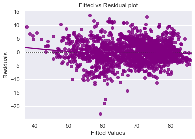

```python
# let's plot the fitted values vs residuals

sns.residplot(
    data=df_pred, x="Fitted Values", y="Residuals", color="purple", lowess=True
)
plt.xlabel("Fitted Values")
plt.ylabel("Residuals")
plt.title("Fitted vs Residual plot")
plt.show()
```

- The scatter plot shows the distribution of residuals (errors) vs fitted values (predicted values).
- If there exist any pattern in this plot, we consider it as signs of non-linearity in the data and a pattern means that the model doesn't capture non-linear effects.
- **We see no pattern in the plot above. Hence, the assumptions of linearity and independence are satisfied.**

### TEST FOR NORMALITY

**Why the test?**

- Error terms, or residuals, should be normally distributed. If the error terms are not normally distributed, confidence intervals of the coefficient estimates may become too wide or narrow. Once confidence interval becomes unstable, it leads to difficulty in estimating coefficients based on minimization of least squares. Non-normality suggests that there are a few unusual data points that must be studied closely to make a better model.

**How to check normality?**

- The shape of the histogram of residuals can give an initial idea about the normality.
- It can also be checked via a Q-Q plot of residuals. If the residuals follow a normal distribution, they will make a straight line plot, otherwise not.
- Other tests to check for normality includes the Shapiro-Wilk test.
  - Null hypothesis: Residuals are normally distributed
  - Alternate hypothesis: Residuals are not normally distributed

**How to fix if this assumption is not followed?**

- We can apply transformations like log, exponential, arcsinh, etc. as per our data.

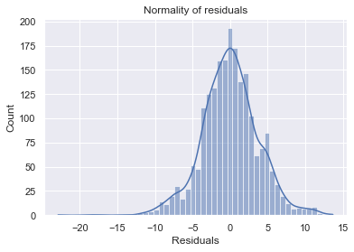

```python
sns.histplot(data=df_pred, x="Residuals", kde=True)
plt.title("Normality of residuals")
plt.show()
```

- The histogram of residuals does have a bell shape.
- Let's check the Q-Q plot.

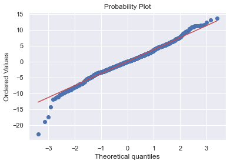

```python
import pylab
import scipy.stats as stats

stats.probplot(df_pred["Residuals"], dist="norm", plot=pylab)
plt.show()
```

- The residuals more or less follow a straight line except for the tails.
- Let's check the results of the Shapiro-Wilk test.

```python
stats.shapiro(df_pred["Residuals"])
```

```
ShapiroResult(statistic=0.9869109988212585, pvalue=9.742823952121893e-13)
```

- Since p-value < 0.05, the residuals are not normal as per the Shapiro-Wilk test.
- Strictly speaking, the residuals are not normal.
- However, as an approximation, we can accept this distribution as close to being normal.
- **So, the assumption is satisfied.**

### TEST FOR HOMOSCEDASTICITY

- **Homoscedascity**: If the variance of the residuals is symmetrically distributed across the regression line, then the data is said to be homoscedastic.
- **Heteroscedascity**: If the variance is unequal for the residuals across the regression line, then the data is said to be heteroscedastic.

**Why the test?**

- The presence of non-constant variance in the error terms results in heteroscedasticity. Generally, non-constant variance arises in presence of outliers.

**How to check for homoscedasticity?**

- The residual vs fitted values plot can be looked at to check for homoscedasticity. In the case of heteroscedasticity, the residuals can form an arrow shape or any other non-symmetrical shape.
- The goldfeldquandt test can also be used. If we get a p-value > 0.05 we can say that the residuals are homoscedastic. Otherwise, they are heteroscedastic.
  - Null hypothesis: Residuals are homoscedastic
  - Alternate hypothesis: Residuals have heteroscedasticity

**How to fix if this assumption is not followed?**

- Heteroscedasticity can be fixed by adding other important features or making transformations.

```python
import statsmodels.stats.api as sms
from statsmodels.compat import lzip

name = ["F statistic", "p-value"]
test = sms.het_goldfeldquandt(df_pred["Residuals"], x_train5)
lzip(name, test)
```

```
[('F statistic', 0.9830406677988949), ('p-value', 0.6067961354027434)]
```

**Since p-value > 0.05, we can say that the residuals are homoscedastic. So, this assumption is satisfied.**

**Now that we have checked all the assumptions of linear regression and they are satisfied, let's go ahead with prediction.**

```python
# predictions on the test set
pred = olsmod2.predict(x_test5)

df_pred_test = pd.DataFrame({"Actual": y_test, "Predicted": pred})
df_pred_test.sample(10, random_state=1)
```

|  | Actual | Predicted |
| --- | --- | --- |
| 45 | 71.6 | 66.185783 |
| 1294 | 79.9 | 79.784195 |
| 187 | 75.2 | 75.787198 |
| 661 | 78.8 | 78.745847 |
| 2788 | 52.2 | 55.639856 |
| 151 | 73.0 | 72.287647 |
| 2845 | 71.4 | 67.126506 |
| 1639 | 83.0 | 78.023254 |
| 393 | 72.2 | 73.905880 |
| 1607 | 76.7 | 71.833115 |

- We can observe here that our model has returned pretty good prediction results, and the actual and predicted values are comparable.
- We can also visualize comparison result as a bar graph.

**Note**: As the number of records is large, for representation purpose, we are taking a sample of 25 records only.

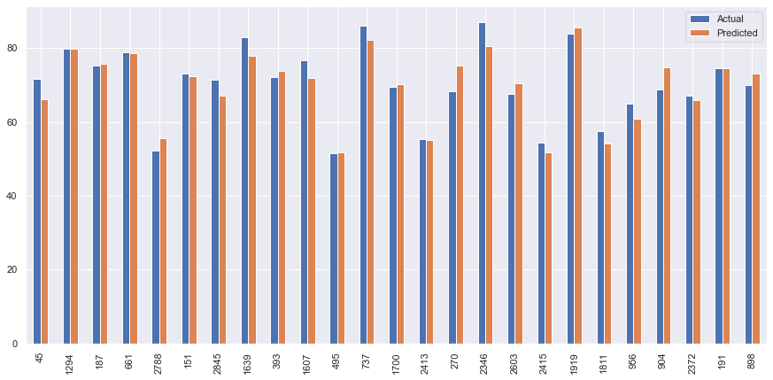

```python
df1 = df_pred_test.sample(25, random_state=1)
df1.plot(kind="bar", figsize=(15, 7))
plt.show()
```

```python
# checking model performance on train set (seen 70% data)
print("Training Performance\n")
olsmod2_train_perf = model_performance_regression(olsmod2, x_train5, y_train)
olsmod2_train_perf
```

```
Training Performance
```

|  | RMSE | MAE | R-squared | Adj. R-squared | MAPE |
| --- | --- | --- | --- | --- | --- |
| 0 | 3.788223 | 2.869585 | 0.843498 | 0.841954 | 4.369148 |

```python
# checking model performance on test set (seen 30% data)
print("Test Performance\n")
olsmod2_test_perf = model_performance_regression(olsmod2, x_test5, y_test)
olsmod2_test_perf
```

```
Test Performance
```

|  | RMSE | MAE | R-squared | Adj. R-squared | MAPE |
| --- | --- | --- | --- | --- | --- |
| 0 | 3.770886 | 2.854912 | 0.838908 | 0.835153 | 4.333436 |

- The model is able to explain ~84% of the variation in the data, which is very good.
- The train and test RMSE and MAE are low and comparable. So, our model is not suffering from overfitting.
- The MAPE on the test set suggests we can predict within 4.3% of the life expectancy.
- Hence, we can conclude the model *olsmod2* is good for prediction as well as inference purposes.

```python
# training performance comparison

models_train_comp_df = pd.concat(
    [olsmodel_train_perf.T, olsmod2_train_perf.T],
    axis=1,
)

models_train_comp_df.columns = [
    "Linear Regression (all variables)",
    "Linear Regression (selected variables)",
]

print("Training performance comparison:")
models_train_comp_df
```

```
Training performance comparison:
```

|  | Linear Regression (all variables) | Linear Regression (selected variables) |
| --- | --- | --- |
| RMSE | 3.744400 | 3.788223 |
| MAE | 2.832731 | 2.869585 |
| R-squared | 0.847098 | 0.843498 |
| Adj. R-squared | 0.845132 | 0.841954 |
| MAPE | 4.308428 | 4.369148 |

```python
# test performance comparison

models_test_comp_df = pd.concat(
    [olsmodel_test_perf.T, olsmod2_test_perf.T],
    axis=1,
)

models_test_comp_df.columns = [
    "Linear Regression (all variables)",
    "Linear Regression (selected variables)",
]

print("Test performance comparison:")
models_test_comp_df
```

```
Test performance comparison:
```

|  | Linear Regression (all variables) | Linear Regression (selected variables) |
| --- | --- | --- |
| RMSE | 3.730845 | 3.770886 |
| MAE | 2.820497 | 2.854912 |
| R-squared | 0.842311 | 0.838908 |
| Adj. R-squared | 0.837499 | 0.835153 |
| MAPE | 4.280578 | 4.333436 |

- The performance of the two models is close to each other.

**Let's recreate the final statsmodels model and print it's summary to gain insights.**

```python
olsmodel_final = sm.OLS(y_train, x_train5).fit()
print(olsmodel_final.summary())
```

```
                            OLS Regression Results
==============================================================================
Dep. Variable:        Life expectancy   R-squared:                       0.843
Model:                            OLS   Adj. R-squared:                  0.842
Method:                 Least Squares   F-statistic:                     575.6
Date:                Fri, 08 Oct 2021   Prob (F-statistic):               0.00
Time:                        10:30:26   Log-Likelihood:                -5636.5
No. Observations:                2049   AIC:                         1.131e+04
Df Residuals:                    2029   BIC:                         1.143e+04
Df Model:                          19
Covariance Type:            nonrobust
===================================================================================================
                                      coef    std err          t      P>|t|      [0.025      0.975]
---------------------------------------------------------------------------------------------------
const                             -23.1832     39.635     -0.585      0.559    -100.913      54.547
Year                                0.0395      0.020      1.994      0.046       0.001       0.078
Adult Mortality                    -0.0162      0.001    -17.819      0.000      -0.018      -0.014
Alcohol                            -0.0801      0.033     -2.395      0.017      -0.146      -0.015
Percentage expenditure              0.0003   4.96e-05      6.128      0.000       0.000       0.000
Hepatitis B                        -0.0163      0.004     -3.821      0.000      -0.025      -0.008
BMI                                 0.0346      0.006      5.860      0.000       0.023       0.046
Under-five deaths                  -0.0023      0.001     -3.794      0.000      -0.004      -0.001
Polio                               0.0346      0.005      6.960      0.000       0.025       0.044
Diphtheria                          0.0344      0.005      6.688      0.000       0.024       0.045
HIV/AIDS                           -0.3813      0.020    -18.604      0.000      -0.422      -0.341
Thinness 5-9 years                 -0.0777      0.029     -2.669      0.008      -0.135      -0.021
Income composition of resources     4.5468      0.721      6.302      0.000       3.132       5.962
Schooling                           0.6184      0.048     12.789      0.000       0.524       0.713
Status_Developing                  -2.6234      0.353     -7.442      0.000      -3.315      -1.932
Continent_Asia                      4.7406      0.281     16.862      0.000       4.189       5.292
Continent_Europe                    4.3902      0.411     10.694      0.000       3.585       5.195
Continent_North America             6.2753      0.360     17.417      0.000       5.569       6.982
Continent_Oceania                   2.7757      0.456      6.089      0.000       1.882       3.670
Continent_South America             4.4261      0.440     10.062      0.000       3.563       5.289
==============================================================================
Omnibus:                       80.001   Durbin-Watson:                   2.014
Prob(Omnibus):                  0.000   Jarque-Bera (JB):              214.140
Skew:                          -0.138   Prob(JB):                     3.16e-47
Kurtosis:                       4.559   Cond. No.                     1.14e+06
==============================================================================

Notes:
[1] Standard Errors assume that the covariance matrix of the errors is correctly specified.
[2] The condition number is large, 1.14e+06. This might indicate that there are
strong multicollinearity or other numerical problems.
```

## Insights

1. Mortality rates (`Under_five_deaths` and `Adult_mortality`) come out to be very significant, as expected. As these two increase, the total life expectancy decreases, as is visible in the negative coefficient sign.
1. 1 unit increase in per capita consumption of pure alcohol (in liters) leads to a decrease in life expectancy by 0.0801 years (~29 days!)
1. Diseases like `Hepatitis_B` and `HIV_AIDS` decrease the life expectancy.
1. Developing countries tend to have ~2.6 years less life expectancy compared to developed countries.
1. People from Asia, Europe, North America, South America, and Oceania have a higher life expectancy than people of Africa.
   - People from North America have ~6.3 years higher life expectancy than people of Africa.
1. `Year`, `Percentage_expenditure`, `Polio` (refers to polio immunization), `Diptheria` (refers to diptheria immunization), `Income composition of resources`, and `Schooling` have positive coefficients. So, as they increase, life expectancy also increases.